# Introduction to Open Data Science - Final assignment

Emanuela Giovanna Calabi

06.03.2017

emanuela.calabi@helsinki.fi

## Abstract

The following analysis was made by a Computer Science undergraduate as final assignment for the MOOC “Introduction to Open Data Science”. The “Human development index” dataset was used for this analysis. The analysis is concerned with the mean years of education in countries of the world and aims to find which factors are associated with a high or low mean. Statistical tools have been uses to read, manipulate and plot data, in particular pairplots, correlation plots, linear regression, linear discriminant analysis and k-means using the R programming language.

## Introduction

The object of this analysis is the Human Development Index. The “human” dataset contains various indicators for each country, which quantify socio-economical wealth and gender equality of such country. More info on the data can be found here: http://hdr.undp.org/en/content/human-development-index-hdi.

The following analysis concerns the the mean years of education (edu.mean) and its relations to the other variables in the set. I expect that countries with a higher edu.mean have a high Gross National Income per capita, longer life expectancy at birth and longer expectancy of education. On the contrary, I suppose that a lower edu.mean corresponds to a higher Gender Inequality Index and a higher adolescent birthrate.

## Data wrangling

The “human” dataset has been created by joining two datasets (“human_development” and “gender_inequality”). Variables have been renamed to shorter and more intuitive names for practical reasons. The last 7 observations concerning regions of the world have been removed to focus on countries only. In the end 8 variables were selected to keep for the analysis. Such manipulations of the dataset can be found in my data wrangling exercise at this link: https://github.com/egcmi/IODS-final/blob/master/create_human.R

## Data analysis

Let us start by reading and exploring the data.

```r
human <- read.csv("~/Desktop/IODS/IODS-final/human.txt", header=TRUE, row.names=1)
dim(human)
```

```
## [1] 155   8
```

There are 155 observations of 8 variables, i.e. 155 countries are taken into consideration. The variable names and their meanings are:

- **edu2.fm**: Ratio between females and males with secondary education
- **life.exp**: Life expectancy at birth
- **edu.exp**: Expected years of education
- **edu.mean**: Mean years of education
- **GNI**: Gross National Income per capita
- **GII**: Gender Inequality Index
- **mat.mor**: Maternal mortality ratio
- **ado.birth**: Adolescent birthrate

```r
str(human)
```

```
## 'data.frame':    155 obs. of  8 variables:
##  $ edu2.fm  : num  1.007 0.997 0.983 0.989 0.969 ...
##  $ life.exp : num  81.6 82.4 83 80.2 81.6 80.9 80.9 79.1 82 81.8 ...
##  $ edu.exp  : num  17.5 20.2 15.8 18.7 17.9 16.5 18.6 16.5 15.9 19.2 ...
##  $ edu.mean : num  12.6 13 12.8 12.7 11.9 13.1 12.2 12.9 13 12.5 ...
##  $ GNI      : int  64992 42261 56431 44025 45435 43919 39568 52947 42155 32689 ...
##  $ GII      : num  0.067 0.11 0.028 0.048 0.062 0.041 0.113 0.28 0.129 0.157 ...
##  $ mat.mor  : int  4 6 6 5 6 7 9 28 11 8 ...
##  $ ado.birth: num  7.8 12.1 1.9 5.1 6.2 3.8 8.2 31 14.5 25.3 ...
```

```r
summary(human)
```

```
##     edu2.fm          life.exp        edu.exp         edu.mean
##  Min.   :0.1717   Min.   :49.00   Min.   : 5.40   Min.   : 1.400
##  1st Qu.:0.7264   1st Qu.:66.30   1st Qu.:11.25   1st Qu.: 6.000
##  Median :0.9375   Median :74.20   Median :13.50   Median : 8.500
##  Mean   :0.8529   Mean   :71.65   Mean   :13.18   Mean   : 8.302
##  3rd Qu.:0.9968   3rd Qu.:77.25   3rd Qu.:15.20   3rd Qu.:10.900
##  Max.   :1.4967   Max.   :83.50   Max.   :20.20   Max.   :13.100
##       GNI              GII            mat.mor         ado.birth
##  Min.   :   581   Min.   :0.0160   Min.   :   1.0   Min.   :  0.60
##  1st Qu.:  4198   1st Qu.:0.1840   1st Qu.:  11.5   1st Qu.: 12.65
##  Median : 12040   Median :0.3850   Median :  49.0   Median : 33.60
##  Mean   : 17628   Mean   :0.3659   Mean   : 149.1   Mean   : 47.16
##  3rd Qu.: 24512   3rd Qu.:0.5245   3rd Qu.: 190.0   3rd Qu.: 71.95
##  Max.   :123124   Max.   :0.7440   Max.   :1100.0   Max.   :204.80
```

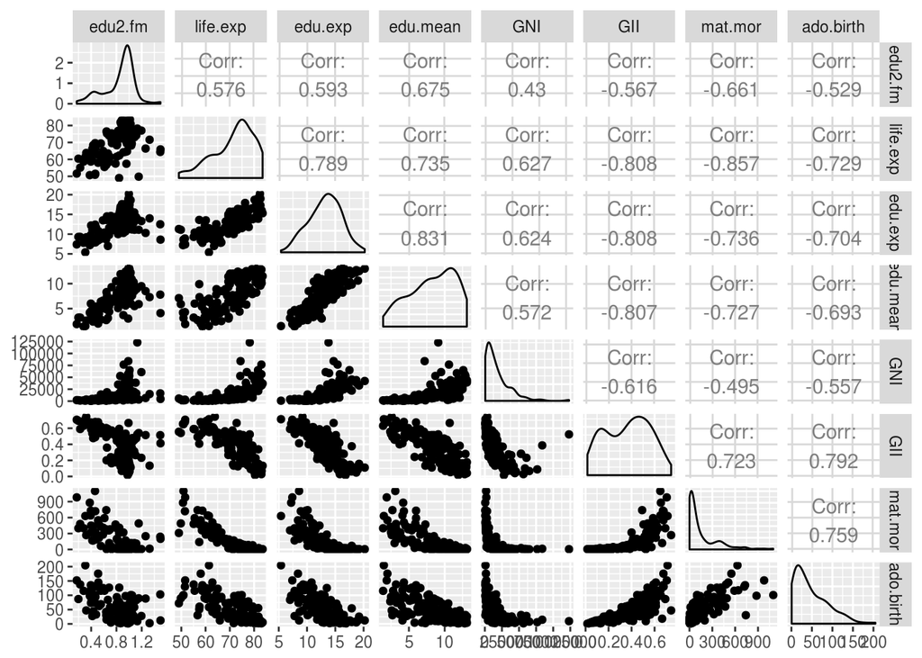

```r
library(GGally)
ggpairs(human)
```

Let us plot the correlation between the variables in the dataset. We can see that edu2.fm is positively correlated to life.exp, edu.exp, edu.mean and GNI and all these variables are strongly positively correlated to each other. Notice how the graph appears split by a big, red rectangle indicating strong negative correlation. The variables concerned in such rectangle are GII, mat.mor and ado.birth which negatively correlate to all other variables. Unsurprisingly GII, mat.mor and ado.birth are strongly positively correlated, meaning that maternal mortality and adolescent birthrate are higher in such countries where gender inequality is stronger.

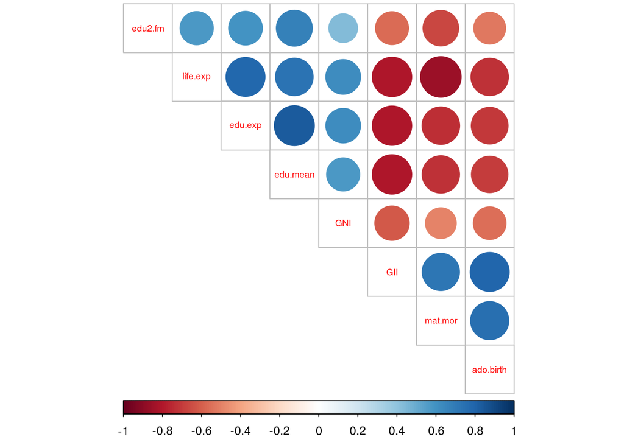

```r
library(magrittr)
library(corrplot)
cor(human) %>% corrplot(method="circle", type="upper", cl.pos="b", tl.pos="d", tl.cex=0.6)
```

### Linear regression

```r
lm(edu.mean ~ edu.exp + life.exp + edu2.fm, data=human) %>% summary
```

```
##
## Call:
## lm(formula = edu.mean ~ edu.exp + life.exp + edu2.fm, data = human)
##
## Residuals:
##    Min     1Q Median     3Q    Max
## -5.273 -1.080  0.059  1.280  3.381
##
## Coefficients:
##             Estimate Std. Error t value Pr(>|t|)
## (Intercept) -6.52908    1.20259  -5.429 2.21e-07 ***
## edu.exp      0.63093    0.07656   8.241 7.63e-14 ***
## life.exp     0.05108    0.02570   1.987   0.0487 *
## edu2.fm      3.35096    0.67577   4.959 1.89e-06 ***
## ---
## Signif. codes:  0 '***' 0.001 '**' 0.01 '*' 0.05 '.' 0.1 ' ' 1
##
## Residual standard error: 1.592 on 151 degrees of freedom
## Multiple R-squared:  0.7478, Adjusted R-squared:  0.7428
## F-statistic: 149.3 on 3 and 151 DF,  p-value: < 2.2e-16
```

### Linear discriminant analysis

Now let us perform Linear Discriminant Analysis in order to make predictions about the target variable edu.mean. The explanatory variables are edu.exp, life.exp and edu2.fm. As we can see in the Proportion of trace, Linear Discriminant 1 (LD1) describes 71.7% of the variance in the group. According to the coefficients of linear discriminants the explanatory variables are all relevant to edu.mean, being edu2.fm the most influent.

```r
library(MASS)
lda_human <- lda(edu.mean ~ edu.exp + life.exp + edu2.fm, data=human)
lda_human
```

```
## Call:
## lda(edu.mean ~ edu.exp + life.exp + edu2.fm, data = human)
##
## Prior probabilities of groups:
##         1.4         1.5         1.9           2         2.4         2.5
## 0.006451613 0.006451613 0.006451613 0.006451613 0.006451613 0.006451613
##         2.6         2.7         2.8           3         3.1         3.2
## 0.006451613 0.006451613 0.006451613 0.006451613 0.012903226 0.012903226
##         3.3         3.7         3.8           4         4.1         4.2
## 0.012903226 0.006451613 0.006451613 0.006451613 0.012903226 0.006451613
##         4.3         4.4         4.5         4.7         4.9         5.1
## 0.012903226 0.012903226 0.006451613 0.006451613 0.006451613 0.012903226
##         5.4         5.5         5.6         5.8         5.9           6
## 0.012903226 0.006451613 0.006451613 0.006451613 0.006451613 0.019354839
##         6.1         6.2         6.3         6.4         6.5         6.6
## 0.006451613 0.006451613 0.012903226 0.006451613 0.006451613 0.012903226
##         6.8           7         7.1         7.2         7.3         7.5
## 0.006451613 0.006451613 0.006451613 0.006451613 0.025806452 0.012903226
##         7.6         7.7         7.8         7.9           8         8.2
## 0.032258065 0.019354839 0.006451613 0.006451613 0.006451613 0.019354839
##         8.3         8.4         8.5         8.7         8.9           9
## 0.006451613 0.006451613 0.025806452 0.006451613 0.019354839 0.006451613
##         9.1         9.3         9.4         9.5         9.6         9.7
## 0.006451613 0.025806452 0.006451613 0.006451613 0.006451613 0.006451613
##         9.8         9.9          10        10.1        10.3        10.4
## 0.012903226 0.019354839 0.006451613 0.006451613 0.025806452 0.006451613
##        10.5        10.6        10.7        10.8        10.9          11
## 0.019354839 0.025806452 0.006451613 0.019354839 0.019354839 0.006451613
##        11.1        11.2        11.3        11.4        11.5        11.6
## 0.006451613 0.019354839 0.012903226 0.006451613 0.019354839 0.012903226
##        11.7        11.8        11.9          12        12.1        12.2
## 0.006451613 0.006451613 0.019354839 0.012903226 0.012903226 0.012903226
##        12.3        12.4        12.5        12.6        12.7        12.8
## 0.006451613 0.006451613 0.019354839 0.006451613 0.006451613 0.006451613
##        12.9          13        13.1
## 0.006451613 0.012903226 0.012903226
##
## Group means:
##       edu.exp life.exp   edu2.fm
## 1.4   7.80000 58.70000 0.2812500
```

[output cut: 87 more lines]

```
## 12.7 18.70000 80.20000 0.9886128
## 12.8 15.80000 83.00000 0.9834369
## 12.9 16.50000 79.10000 1.0031646
## 13   18.05000 82.20000 0.9984144
## 13.1 16.35000 80.80000 0.9958913
##
## Coefficients of linear discriminants:
##                 LD1        LD2        LD3
## edu.exp  0.51670458 -0.1800841 -0.5509670
## life.exp 0.01703982  0.2001363  0.1153165
## edu2.fm  3.41999111 -4.4291032  3.5646545
##
## Proportion of trace:
##    LD1    LD2    LD3
## 0.7166 0.1697 0.1137
```

Our next step is visualising the LDA by means of LDA biplot arrows. In the scatterplot we can see from the length of the arrows, edu2.fm is the variable which has the largest impact on edu.mean. Edu.exp and life.exp have minor influence.

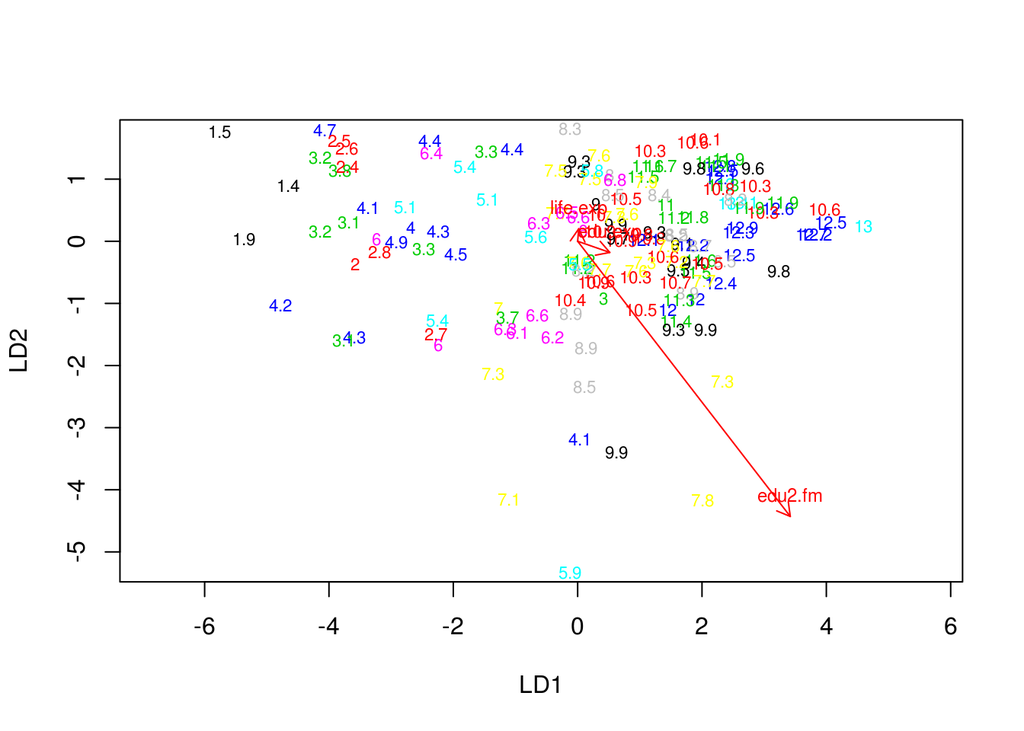

```r
lda.arrows <- function(x, myscale = 1, arrow_heads = 0.1, color = "red", tex = 0.75, choices = c(1,2)){
  heads <- coef(x)
  arrows(x0 = 0, y0 = 0,
         x1 = myscale * heads[,choices[1]],
         y1 = myscale * heads[,choices[2]], col=color, length = arrow_heads)
  text(myscale * heads[,choices], labels = row.names(heads),
       cex = tex, col=color, pos=3)
}

plot(lda_human, col=human$edu.mean, pch=human$edu.mean, dimen=2)
lda.arrows(lda_human, myscale = 1)
```

### K-means

The final step of our analysis is K-means. The first step for K-means is finding the number of clusters that are needed. For this reason we compute the *total within cluster sum of squares* (TWCSS) first. We can see in the plot that the TWCSS drops significantly at 2. This means that 2 is the optimal number of clusters.

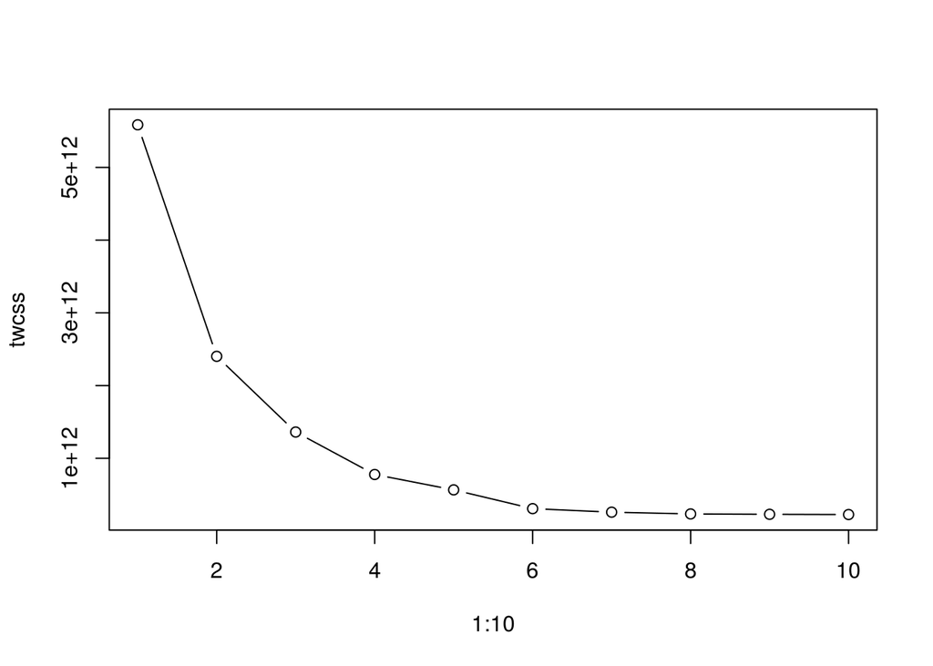

```r
dist_human <- dist(human)
twcss <- sapply(1:10, function(k){kmeans(dist_human, k)$tot.withinss})
plot(1:10, twcss, type='b')
```

After finding out the number of clusters needed, we can proceed and compute K-means. We used the euclidean method to determine the distance between observation. The variable GNI is the one where the difference is most clear compared to the pairplot without clusters.

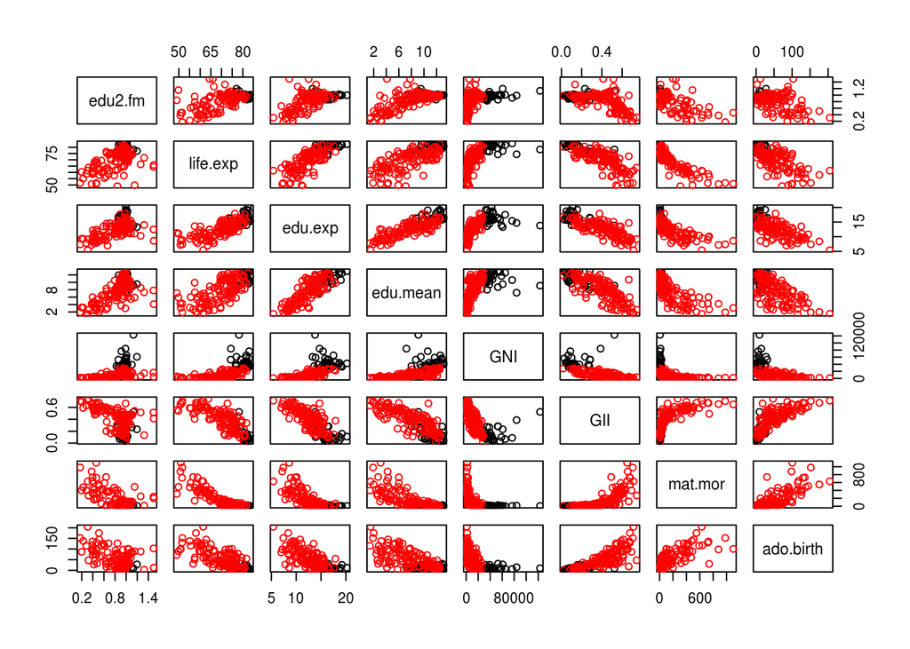

```r
set.seed(123)
km_human <- kmeans(dist_human, centers=2)
pairs(human, col=km_human$cluster)
```

## Conclusion

After the data analisis, it emerges that edu.mean is positively correlated to life.exp, edu.exp, edu2.fm and GNI. Edu.mean can also be explained by taking into consideration edu.exp, life.exp and edu2.fm as explanatory variables. Moreover edu2.fm is the most influent explanatory variable. On the other hand countries with a lower edu.mean experience higher values in GII and ado.birth.